# It Starts at Home

Community Involvement for Language Rejuvenation in Northeast India

Ritwiz Sarma

Madras School of Economics

September 23, 2023

## Argument and roadmap

**Central claim:** Community involvement can sustain language rejuvenation; policymakers have a facilitative role.

1. Endangered languages and language shift
2. Political context and speaker trends
3. The Tai Khamti case study
4. Findings and policy recommendations

## Endangered languages in India

The North East has the largest count in the SPPEL list: **43 endangered languages**.

| Zone | Languages |
| --- | --- |
| North East | 43 |
| Northern | 25 |
| Southern | 20 |
| East Central | 15 |
| Andaman and Nicobar | 9 |
| West Central | 5 |

Source: Zonal division of the SPPEL Endangered Languages List, reproduced from the original presentation.

## Language shift: working definitions

- **Endangered language:** a language at risk of dying out because it lacks speakers.
- **Language shift:** speakers move from their mother tongue toward another dominant language.
- **Majority tongue:** the area’s default language for much information about education and public affairs.

## Did autonomy deliver?

| Year | Political change |
| --- | --- |
| 1953 | States Reorganisation Commission formed |
| 1963 | Nagaland created |
| 1970 | Meghalaya becomes an autonomous state |
| 1972 | Tripura and Manipur become states |
| 1987 | Mizoram and Arunachal Pradesh created |

> “Even the smallest of the mini states of north-east India is anything but culturally or linguistically homogeneous.”

Baruah, S. (1989). “Minority Policy in the North-East: Achievements and Dangers.” *Economic and Political Weekly*, 24(37), 2087–2091.

## Scheduled-language speaker trends

**26.7%**

Growth in the share of scheduled-language speakers in Arunachal Pradesh during the 1990s

**223%**

Growth in the share of scheduled-language speakers in Mizoram during the 1990s

**6.53%**

Growth in the share of scheduled-language speakers in Assam during the 2000s

**20.5%**

Growth in the share of scheduled-language speakers in Nagaland during the 2000s

## The Tai Khamti

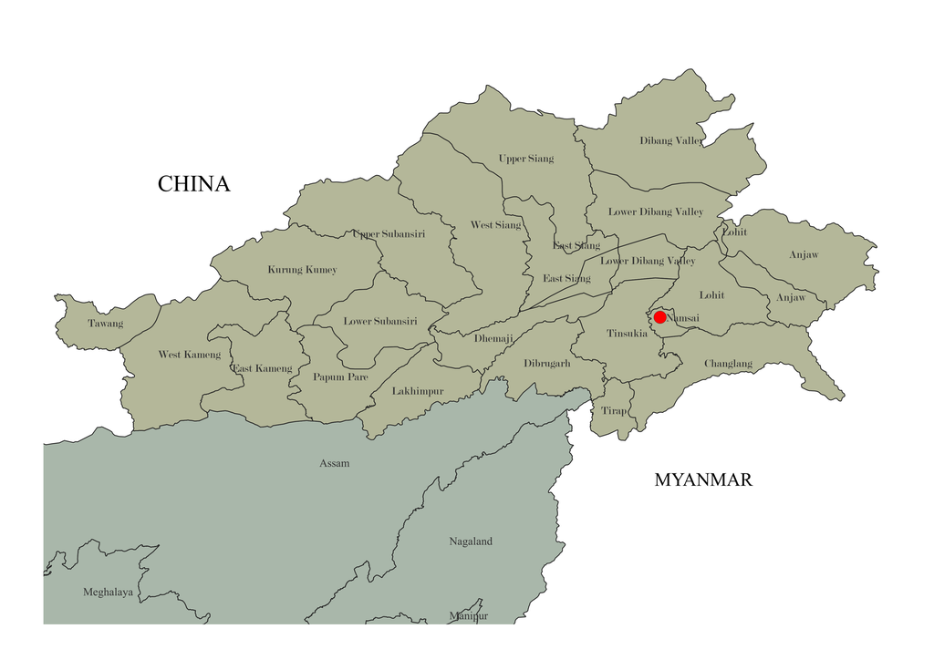

Namsai marked in red.

- Resident in Namsai District
- Two-level social stratification
- A majority or minority language at different subnational levels
- Spoken across economic strata

**Speaker-count estimates**

| Source | Speakers |
| --- | --- |
| Census 2011 | 12,890 |
| Gaur et al. (2022) | 5,000 |
| Morey (2005) | 7,500 |

## Methodology

### Interviews

- Ten semi-structured interviews
- Government workers, teachers, independent artistes, and clergymen
- Respondents aged 25–56; all literate and educated up to graduate level

### Analytical framework

Fishman’s (1991) *reversing language shift* framework guides the case study. Interviews examine:

- Language identification and maintenance
- Indigenous knowledge and documentation
- Linguistic culture, including honorifics
- Narrative forms

## Findings: identification and knowledge

### Community identification

- “thoda Hindi toh bolte hai” — multiple speakers
- Hindi versus Assamese
- Language maintenance from elders to younger speakers
- “We learn English only in school” — Namchoom
- Tai Khamti Heritage and Literary Society
- “Two or three generations from now, Khamti will still be spoken.”

### Indigenous knowledge

- No dictionary; script digitalisation in progress — Mannoi
- No textbooks; teachers use Myanmarese material
- Das and Tag (2004) versus Moungkang
- Indigenous context and its uniqueness (Abbi, 2021)
- Some words cannot be translated and may die with the language

## Findings: honorifics and narratives

### Honorifics

- Honorifics carry over into majority-tongue speech without translation.
- Translation becomes onerous when requested.
- They exemplify “linguistic culture” (Schiffman, 1996).

### Narrative forms

- Almost all have heard folktales; few can remember them.
- “Like my father used to tell me stories, I cannot quite remember that. Some stories I can tell… (but) not quite narrate like that.”
- Stories are unique to the culture, not translations.
- Songs are performed at festivals and distributed physically and online.

## Recommendations

### Cultural programmes

- Ceremonial use reaffirms identity.
- Programmes provide a forum for the community.
- Resource constraint remains.

### Build local capacity

- Include community stakeholders in research and decisions.
- Provide documentation training, tools, and resources.

### Fund data collection

- Large repositories require technical tools.
- Current grants lag those abroad.
- Gaur et al. (2022) report outdated primary data.

### Create reference materials

- Their absence limits language maintenance.
- Community initiative needs support for resource-intensive work.

## Closing thought

> “Only a community can keep its language alive. No governmental or non-governmental initiative is sufficient in this regard.”

Gaur, C. R., Dey, S., & Mamta, K. (2022). *Tribal and Indigenous Languages of India*. UNESCO.